# HW 3a: Penguin t-tests and correlation

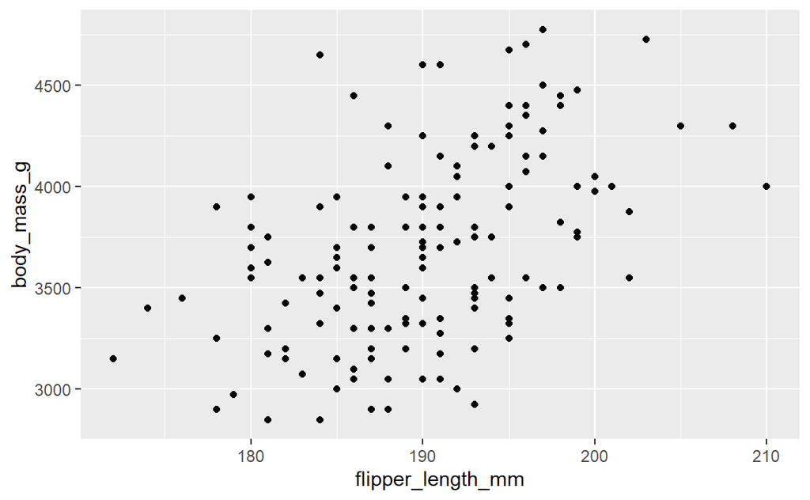

```r
# Overcomplicating things just to see what happens below #
Gentoo= penguins %>%
  filter(species=="Gentoo")

## Adelie details
ggplot()+
  geom_point(aes(x=flipper_length_mm, y=body_mass_g), data=Adelie)
```

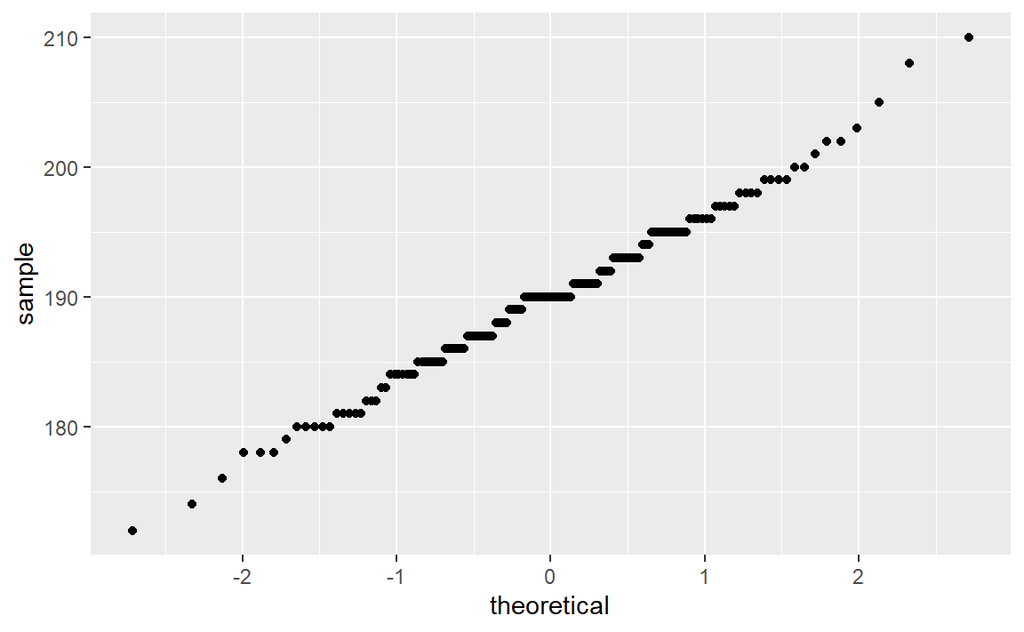

```r
ggplot(Adelie)+
  stat_qq(aes(sample=flipper_length_mm))
```

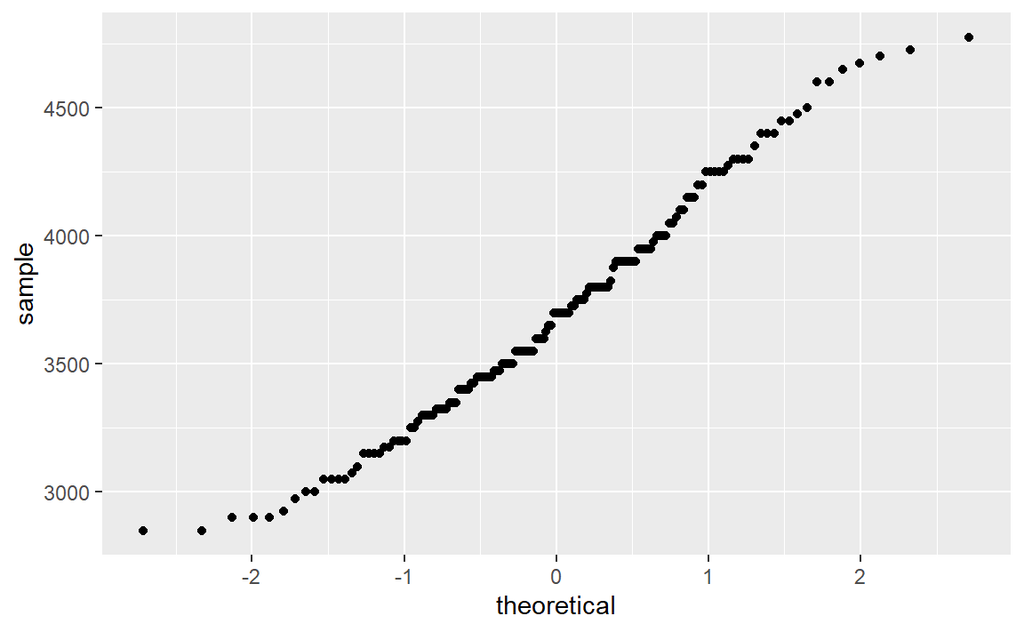

```r
ggplot(Adelie) +
  stat_qq(aes(sample=body_mass_g))
```

```r
cor(x=Adelie$flipper_length_mm, y=Adelie$body_mass_g, use = "complete.obs")
```

```
## [1] 0.4682017
```

```r
# correlation for Adelie= 0.4682

cor.test(x=Adelie$flipper_length_mm, y=Adelie$body_mass_g, use = "complete.obs")
```

```
##
##  Pearson's product-moment correlation
##
## data:  Adelie$flipper_length_mm and Adelie$body_mass_g
## t = 6.4678, df = 149, p-value = 1.343e-09
## alternative hypothesis: true correlation is not equal to 0
## 95 percent confidence interval:
##  0.3334071 0.5842379
## sample estimates:
##       cor
## 0.4682017
```

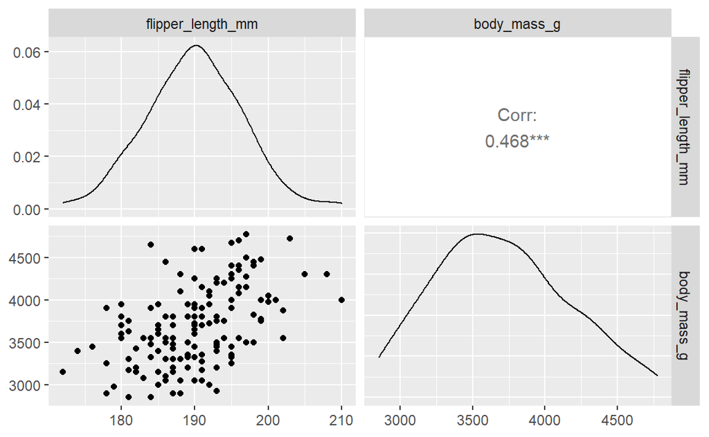

```r
Adelie %>%
  select(flipper_length_mm, body_mass_g) %>%
  GGally::ggpairs()
```

```r
Adelie_flipper_mass_lm = lm(flipper_length_mm ~ body_mass_g, data = penguins)
summary(Adelie_flipper_mass_lm)
```

```
##
## Call:
## lm(formula = flipper_length_mm ~ body_mass_g, data = penguins)
##
## Residuals:
##      Min       1Q   Median       3Q      Max
## -23.7626  -4.9138   0.9891   5.1166  16.6392
##
## Coefficients:
##              Estimate Std. Error t value Pr(>|t|)
## (Intercept) 1.367e+02  1.997e+00   68.47   <2e-16 ***
## body_mass_g 1.528e-02  4.668e-04   32.72   <2e-16 ***
## ---
## Signif. codes:  0 '***' 0.001 '**' 0.01 '*' 0.05 '.' 0.1 ' ' 1
##
## Residual standard error: 6.913 on 340 degrees of freedom
##   (2 observations deleted due to missingness)
## Multiple R-squared:  0.759,  Adjusted R-squared:  0.7583
## F-statistic:  1071 on 1 and 340 DF,  p-value: < 2.2e-16
```

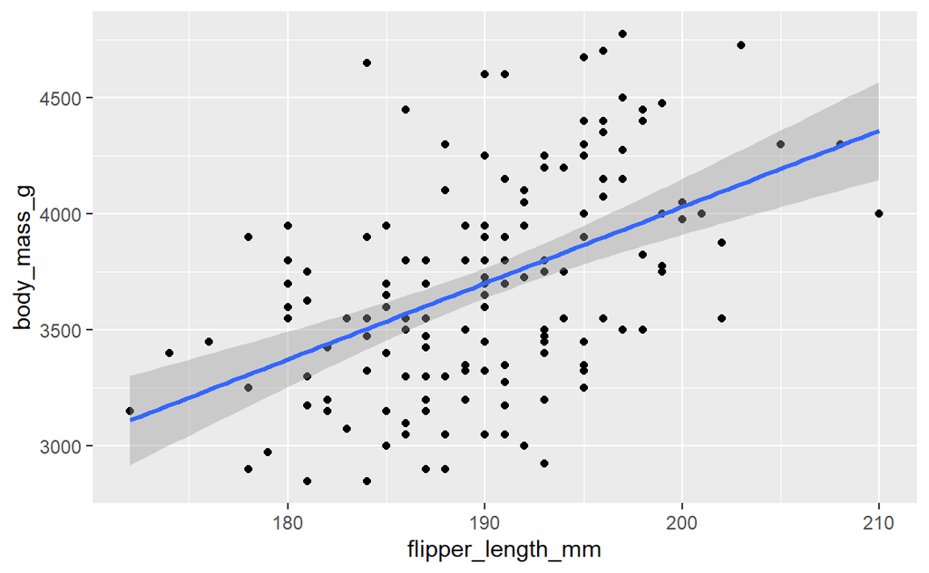

```r
ggplot(data=Adelie, aes(x=flipper_length_mm, y=body_mass_g)) +
  geom_point()+
  geom_smooth(method = "lm")
## `geom_smooth()` using formula 'y ~ x'
## Warning: Removed 1 rows containing non-finite values (stat_smooth).
## Warning: Removed 1 rows containing missing values (geom_point).
```

```r
plot(Adelie_flipper_mass_lm)
```

[output not shown]

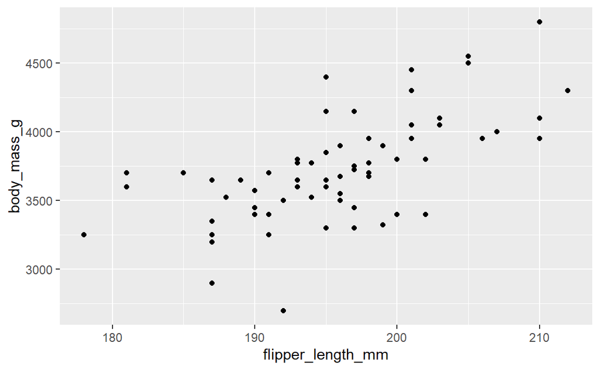

```r
## Chinstrap details

ggplot()+
  geom_point(aes(x=flipper_length_mm, y=body_mass_g), data=Chinstrap)
```

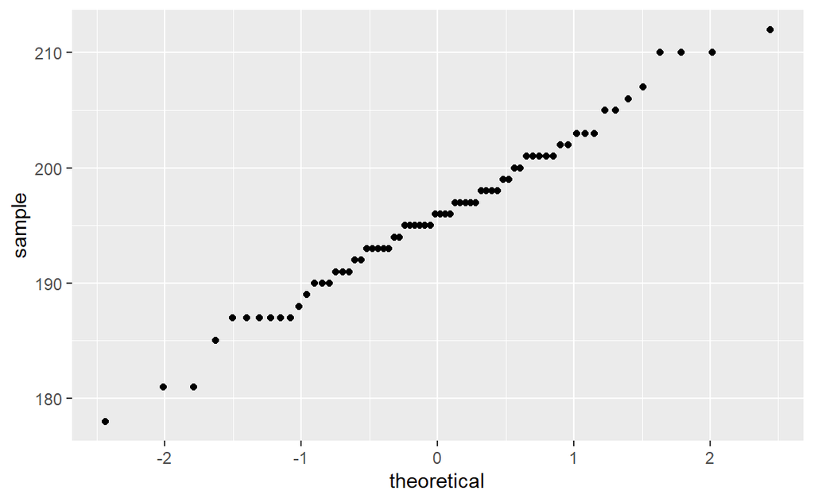

```r
ggplot(Chinstrap)+
  stat_qq(aes(sample=flipper_length_mm))
```

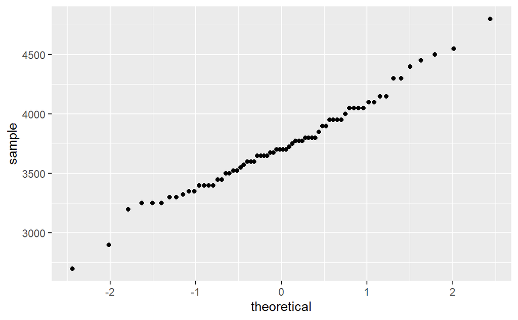

```r
ggplot(Chinstrap) +
  stat_qq(aes(sample=body_mass_g))
```

```r
cor(x=Chinstrap$flipper_length_mm, y=Chinstrap$body_mass_g, use = "complete.obs")
```

```
## [1] 0.6415594
```

```r
# correlation for Chinstrap= 0.6416

cor.test(x=Chinstrap$flipper_length_mm, y=Chinstrap$body_mass_g, use = "complete.obs")
```

```
##
##  Pearson's product-moment correlation
##
## data:  Chinstrap$flipper_length_mm and Chinstrap$body_mass_g
## t = 6.7947, df = 66, p-value = 3.748e-09
## alternative hypothesis: true correlation is not equal to 0
## 95 percent confidence interval:
##  0.4759352 0.7632368
## sample estimates:
##       cor
## 0.6415594
```

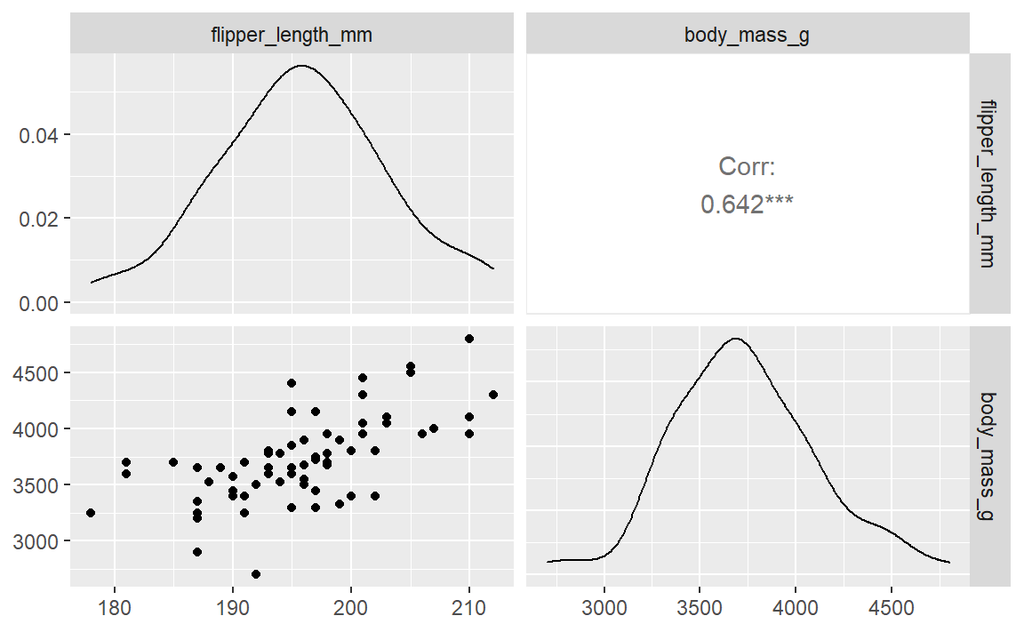

```r
Chinstrap %>%
  select(flipper_length_mm, body_mass_g) %>%
  GGally::ggpairs()
```

```r
Chinstrap_flipper_mass_lm = lm(flipper_length_mm ~ body_mass_g, data = penguins)
summary(Chinstrap_flipper_mass_lm)
```

```
##
## Call:
## lm(formula = flipper_length_mm ~ body_mass_g, data = penguins)
##
## Residuals:
##      Min       1Q   Median       3Q      Max
## -23.7626  -4.9138   0.9891   5.1166  16.6392
##
## Coefficients:
##              Estimate Std. Error t value Pr(>|t|)
## (Intercept) 1.367e+02  1.997e+00   68.47   <2e-16 ***
## body_mass_g 1.528e-02  4.668e-04   32.72   <2e-16 ***
## ---
## Signif. codes:  0 '***' 0.001 '**' 0.01 '*' 0.05 '.' 0.1 ' ' 1
##
## Residual standard error: 6.913 on 340 degrees of freedom
##   (2 observations deleted due to missingness)
## Multiple R-squared:  0.759,  Adjusted R-squared:  0.7583
## F-statistic:  1071 on 1 and 340 DF,  p-value: < 2.2e-16
```

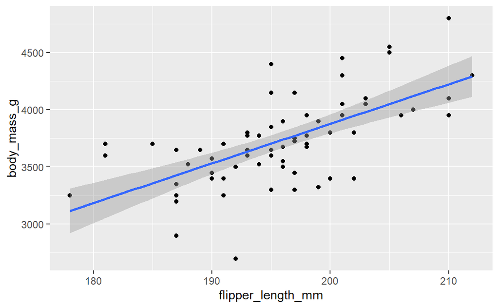

```r
ggplot(data=Chinstrap, aes(x=flipper_length_mm, y=body_mass_g)) +
  geom_point()+
  geom_smooth(method = "lm")
## `geom_smooth()` using formula 'y ~ x'
```

```r
plot(Chinstrap_flipper_mass_lm)
```

[output not shown]

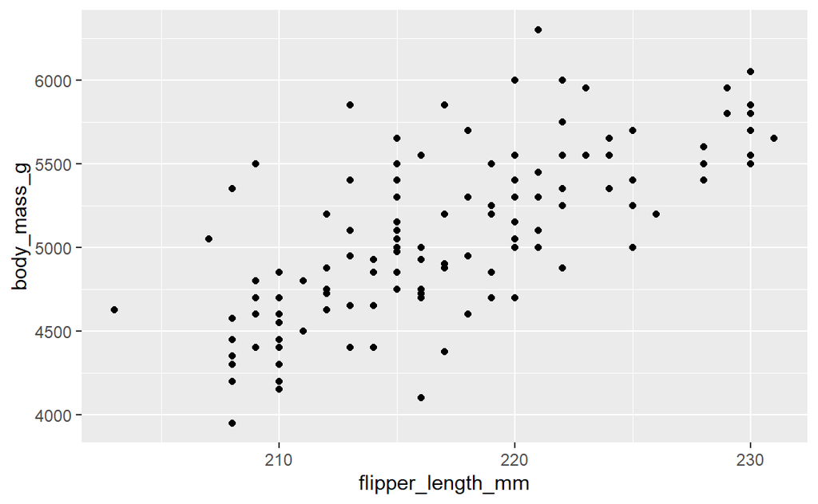

```r
## Gentoo details

ggplot()+
  geom_point(aes(x=flipper_length_mm, y=body_mass_g), data=Gentoo)
```

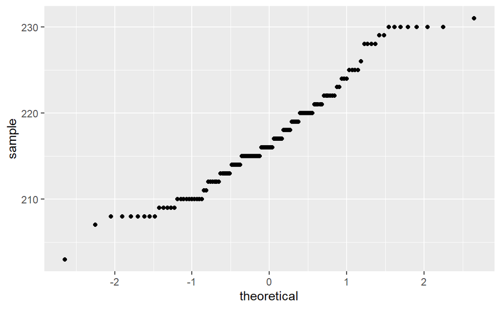

```r
ggplot(Gentoo)+
  stat_qq(aes(sample=flipper_length_mm))
```

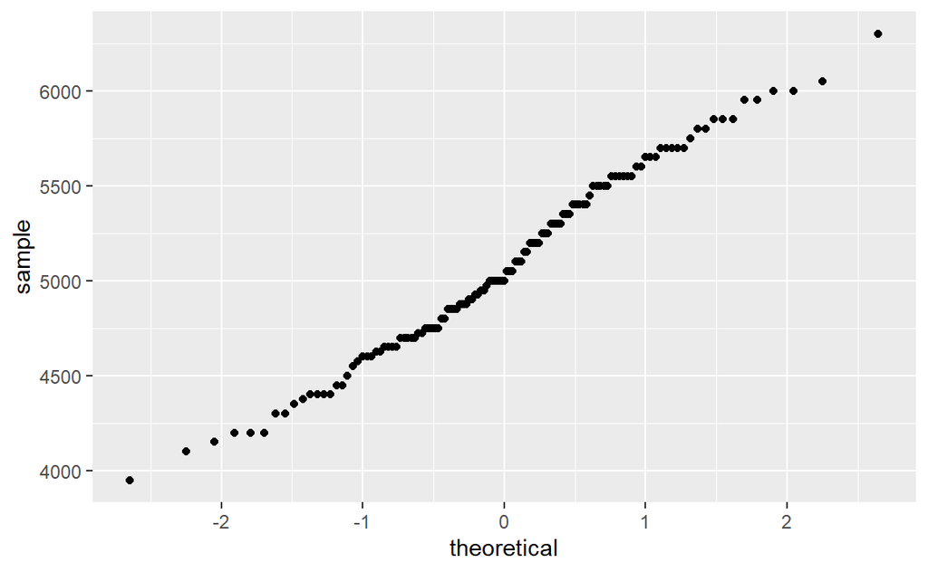

```r
ggplot(Gentoo) +
  stat_qq(aes(sample=body_mass_g))
```

```r
cor(x=Gentoo$flipper_length_mm, y=Gentoo$body_mass_g, use = "complete.obs")
```

```
## [1] 0.7026665
```

```r
# correlation for Gentoo= 0.7027

cor.test(x=Gentoo$flipper_length_mm, y=Gentoo$body_mass_g, use = "complete.obs")
```

```
##
##  Pearson's product-moment correlation
##
## data:  Gentoo$flipper_length_mm and Gentoo$body_mass_g
## t = 10.863, df = 121, p-value < 2.2e-16
## alternative hypothesis: true correlation is not equal to 0
## 95 percent confidence interval:
##  0.6003082 0.7823763
## sample estimates:
##       cor
## 0.7026665
```

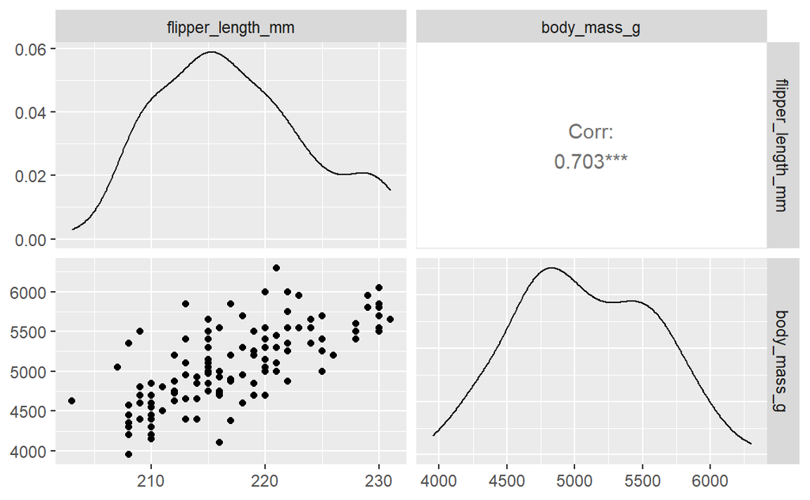

```r
Gentoo %>%
  select(flipper_length_mm, body_mass_g) %>%
  GGally::ggpairs()
```

```r
Gentoo_flipper_mass_lm = lm(flipper_length_mm ~ body_mass_g, data = penguins)
summary(Gentoo_flipper_mass_lm)
```

```
##
## Call:
## lm(formula = flipper_length_mm ~ body_mass_g, data = penguins)
##
## Residuals:
##      Min       1Q   Median       3Q      Max
## -23.7626  -4.9138   0.9891   5.1166  16.6392
##
## Coefficients:
##              Estimate Std. Error t value Pr(>|t|)
## (Intercept) 1.367e+02  1.997e+00   68.47   <2e-16 ***
## body_mass_g 1.528e-02  4.668e-04   32.72   <2e-16 ***
## ---
## Signif. codes:  0 '***' 0.001 '**' 0.01 '*' 0.05 '.' 0.1 ' ' 1
##
## Residual standard error: 6.913 on 340 degrees of freedom
##   (2 observations deleted due to missingness)
## Multiple R-squared:  0.759,  Adjusted R-squared:  0.7583
## F-statistic:  1071 on 1 and 340 DF,  p-value: < 2.2e-16
```

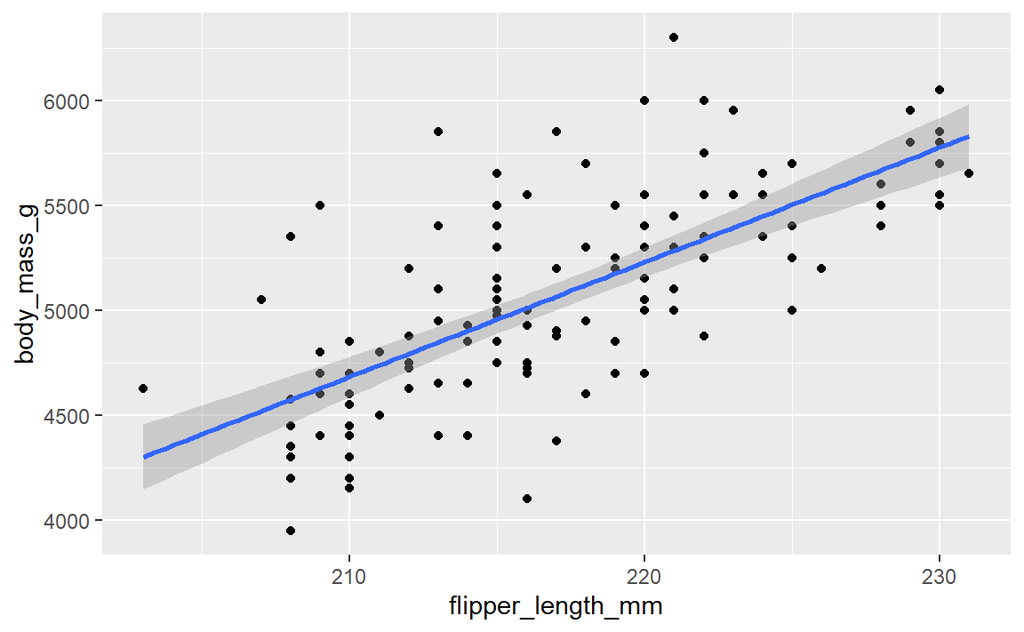

```r
ggplot(data=Gentoo, aes(x=flipper_length_mm, y=body_mass_g)) +
  geom_point()+
  geom_smooth(method = "lm")
## `geom_smooth()` using formula 'y ~ x'
## Warning: Removed 1 rows containing non-finite values (stat_smooth).
## Warning: Removed 1 rows containing missing values (geom_point).
```

```r
plot(Gentoo_flipper_mass_lm)
```

[output not shown]

- The correlation between flipper length and body mass for Adelie penguins is 0.4682. This was the species in which flipper length and body mass were least correlated.
- The correlation between flipper length and body mass for Chinstrap penguins is 0.6416
- The correlation between flipper length and body mass for Gentoo penguins is 0.7027. This was the species in which flipper length and body mass were most correlated.

For these questions, start with a bit of data exploration. Plot the data and provide summary statistics. Then explain what statistical test you are going to use and explicitly list and test the assumptions for that test. Answer each question clearly by providing a written answer that could be included in a report.